# Common problems with lab 3

Generally, yesterday’s homework was excellent! Well done! Some small things:

1. When interpreting regression coefficients, there were some common errors:
   1. Failing to specify the unit of the independent variable (i.e. “an increase in price is associated with a 0.05 reduction in sales” or “a unit increase in year”)
   2. Failing to mention that other variables are held constant.
   3. Failing to discuss significance (or reporting on insignificant coefficients)
2. Interpreting `R^2` can be tricky - is explaining .25 of the variation in the dependent variable good? Or bad? The absolute value is difficult to assess, but it can be useful in comparing the fit **accross** different models.
3. Some people put an awful lot of work into calculating the confidence intervals of a regression line by hand. There is a simple way!

```r
x <- 1:100
y <- rnorm(100, mean = x, sd = 10)
model <- lm(y ~ x)
confint(model, level = 0.95)
```

```
##                  2.5 %   97.5 %
## (Intercept) -2.3925719 5.309142
## x            0.9188334 1.051238
```

4. When specifying a regression model, it is normally useful to make use of the `data = x` argument. So, rather than:

```r
lm(Auto$mpg ~ Auto$cylinders + Auto$horsepower + Auto$year)
```

You can instead have:

```r
lm(mpg ~ cylinders + horsepower + year, data = Auto)
```

5. Get to know and love the `par()` function and the `legend()` function.

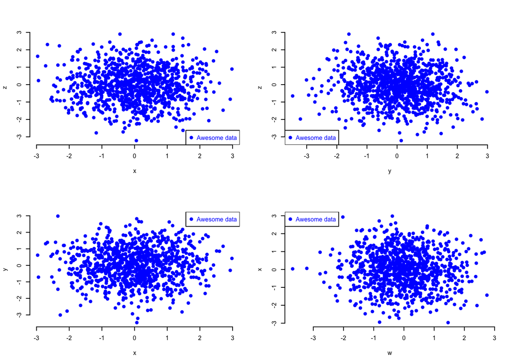

```r
w  <- rnorm(1000)
x  <- rnorm(1000)
y  <- rnorm(1000)
z  <- rnorm(1000)

par(mfrow = c(2,2), col = "blue", pch = 19, cex = 0.5, bty="n")
plot(x, z)
legend("bottomright", legend = "Awesome data", pch = 19)
plot(y, z)
legend("bottomleft", legend = "Awesome data", pch = 19)
plot(x, y)
legend("topright", legend = "Awesome data", pch = 19)
plot(w, x)
legend("topleft", legend = "Awesome data", pch = 19)
```

6. For today’s lab you will need to get to grips with the `predict` function. This is a generic function which can be applied post-estimation to a number of different model objects to produce fitted values. For instance:

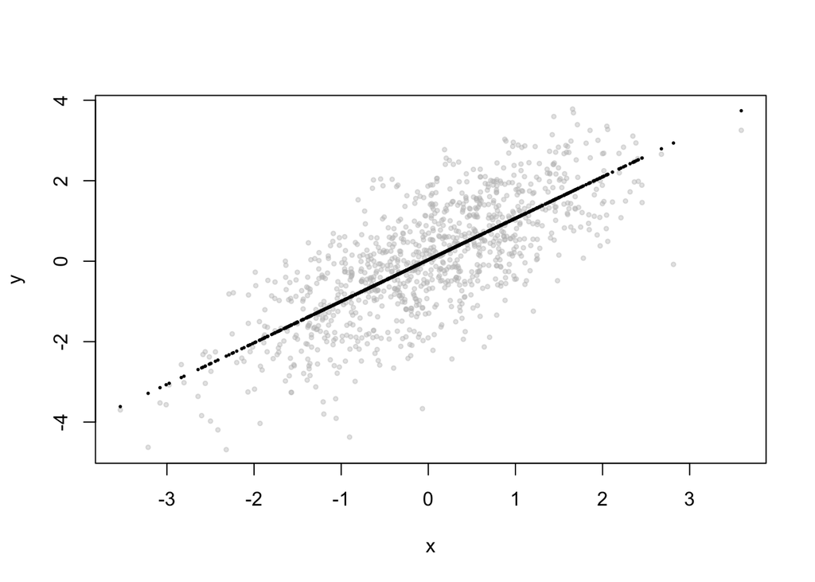

```r
x <- rnorm(1000)
y <- rnorm(1000, mean = x, sd = 1)
model <- lm(y ~ x)
y_hat <- predict(model)
library(scales)
plot(x, y, pch = 19, col = alpha("grey", 0.4), cex = .5)
points(x, y_hat, pch = 19, cex = .25)
```

For producing the fitted *probabilities* for a non-linear model, you will need to modify the `type` argument.

7. Now you are getting to grips with `R`, you could all try and make your code a little more legible. Try using comments which can be included by prefacing with `#`. Also, try giving the objects you create sensible names (i.e. `linear.regression` rather than `obj16`)…

[figure not shown]